# Sesjon 11: Lineære modeller og presentasjon

R-workshop 2. desember, OsloMet

Endelig skal vi gjøre litt analyser!

Her går jeg gjennom de vanligste regresjonstypene. Jeg antar at dere kan regresjoner fra før av, så fokuset mitt er å 1) vise hvordan vi leser resultatene samt 2) tips og triks for å presentere dem.

Det vil si, jeg bruker tid på å vise hvor vi finner relevant informasjon. Alle resultatene lagres i egne modell-objekter. Modell-objektene er lister (se sesjon 2-3 om [objekttyper](https://siljehermansen.github.io/teaching/oslomet/sesjon2.html#lister)) som inneholder ulik informasjon.

I denne sesjonen kommer vi til å bruke følgende pakker:

- `stargazer` : for resultattabeller
- `ggplot2`: for effekt-grafikker
- `dplyr`: for datamanipulering
- `MASS`: for modellering og simulering

# Modellering

Lineære modeller kan uttrykkes som en likning:
$$\begin{equation}
y_i = \alpha + \beta \times x_i + \epsilon_i
\end{equation}$$

R følger denne notasjonen tett. Variablene $x_i$ og $y_i$ er data med mange datapunkter (hvorav indekseringen). Regresjonskoeffisientene og spredningen ($\sigma^2$) til feilleddet/residualene ($\epsilon_i$) finner du i modellstatistikken.

## Modell med én uavhengig variabel

Modeller følger alltid samme oppsett: du velger hvilken modell-funksjon du ønsker å bruke. Inni den presiserer du likningen du skal estimere og dataobjektet hvor du henter informasjonen fra.

Her modellerer jeg respondentens (økonomiske) innvandringsskepsis som en funksjon av vedkommendes arbeidssituasjon.

```r
mod <- lm(formula = Skepsis ~
            Prekaritet,
          data = df)
```

Som vanlig, lagrer jeg modellresultatet i et eget objekt. Mitt favorittnavn er `mod`.

Sjekk resultatet ved å be om et sammendrag. Paradoksalt nok, gir `summary()` mer info enn selve objektet.

```r
#Selve modellobjektet
mod
```

```
##
## Call:
## lm(formula = Skepsis ~ Prekaritet, data = df)
##
## Coefficients:
## (Intercept)   Prekaritet
##       4.377        0.430
```

```r
#Nå sammendraget
summary(mod)
```

```
##
## Call:
## lm(formula = Skepsis ~ Prekaritet, data = df)
##
## Residuals:
##     Min      1Q  Median      3Q     Max
## -4.8066 -1.0432 -0.0432  0.9568  4.9568
##
## Coefficients:
##             Estimate Std. Error t value Pr(>|t|)
## (Intercept)  4.37657    0.04786  91.450  < 2e-16 ***
## Prekaritet   0.43001    0.10732   4.007 6.53e-05 ***
## ---
## Signif. codes:  0 '***' 0.001 '**' 0.01 '*' 0.05 '.' 0.1 ' ' 1
##
## Residual standard error: 1.497 on 1220 degrees of freedom
##   (214 observations deleted due to missingness)
## Multiple R-squared:  0.01299,    Adjusted R-squared:  0.01218
## F-statistic: 16.05 on 1 and 1220 DF,  p-value: 6.527e-05
```

Modellobjektet er en liste med ymse informasjon knyttet til det.

```r
names(mod)
```

```
##  [1] "coefficients"  "residuals"     "effects"       "rank"
##  [5] "fitted.values" "assign"        "qr"            "df.residual"
##  [9] "na.action"     "xlevels"       "call"          "terms"
## [13] "model"
```

**Koeffisientene ($\alpha$ og $\beta$)** Jeg kan trekke ut koeffisientene fra modellobjektet: De er i praksis en vektor med navn.

```r
koef <- mod$coefficients
koef
```

```
## (Intercept)  Prekaritet
##   4.3765747   0.4300096
```

Hva er koeffisienten til “Prekaritet” ($\beta$)?

```r
koef["Prekaritet"]
```

```
## Prekaritet
##  0.4300096
```

Tekstuell tolkning.

```r
paste("Når prekaritet øker med en skalaenhet, øker innvandringsskepsis med",
      round(koef["Prekaritet"],1),
      "skalaenheter.")
```

```
## [1] "Når prekaritet øker med en skalaenhet, øker innvandringsskepsis med 0.4 skalaenheter."
```

**Residualene** ($\epsilon_i$) finner du også her.

```r
mod$residuals[1:10]
```

```
##          1          2          3          4          5          6          7
## -1.3765747  0.2900919  0.9567586  0.6234253 -0.3765747  1.9567586  0.9567586
##          9         10         11
##  0.2900919 -0.1399177  2.8600823
```

Du finner til og med dataene som ble brukt. Her plotter jeg de 6 første observasjonene.

```r
mod$model %>% head()
```

|  | Skepsis | Prekaritet |
| --- | --- | --- |
| 1 | 3.000000 | 0 |
| 2 | 4.666667 | 0 |
| 3 | 5.333333 | 0 |
| 4 | 5.000000 | 0 |
| 5 | 4.000000 | 0 |
| 6 | 6.333333 | 0 |

**Modellsammendraget** gir et godt overblikk. `summary()`-funksjonen returner også en liste med statistikk trukket fra modellobjektet.

```r
summary(mod) %>% names
```

```
##  [1] "call"          "terms"         "residuals"     "coefficients"
##  [5] "aliased"       "sigma"         "df"            "r.squared"
##  [9] "adj.r.squared" "fstatistic"    "cov.unscaled"  "na.action"
```

Her er spredningen ($\sigma$):

```r
summary(mod)$sigma
```

```
## [1] 1.497409
```

Nå kan vi fylle ut likningen.

$$\begin{equation}
y_i = \alpha + \beta \times x_i + \sigma^2 \\
y_i = 4.38+ 0.43 \times x_i + 1.5^2
\end{equation}$$

### Ta vare på resultatene?

Du kan alltid lagre modellobjektet ditt.

```r
save(mod,
     file = "mod.rda")
```

Det er først og fremst nyttig hvis det tok litt tid å estimere modellen. Hvis ikke, kan du ganske enkelt kjøre skriptet ditt på nytt senere.

## Modell med flere uavhengige variabler

Å utvide modellen er uproblematisk. Vanligvis lager jeg da nye modellobjekter, slik at jeg kan ha flere modellresultater for hånd.

Her har jeg kalt den neste modellen min `mod2`. Her kontrollerer jeg for om respondenten eller hans/hennes foreldre er født utenfor Norge.

```r
mod2 <- lm(formula = Skepsis ~
             Prekaritet +
             Innvandrer,
          data = df)
```

```r
summary(mod2)
```

```
##
## Call:
## lm(formula = Skepsis ~ Prekaritet + Innvandrer, data = df)
##
## Residuals:
##    Min     1Q Median     3Q    Max
## -4.574 -1.085 -0.085  0.915  5.199
##
## Coefficients:
##             Estimate Std. Error t value Pr(>|t|)
## (Intercept)    4.419      0.051   86.59  < 2e-16 ***
## Prekaritet     0.439      0.107    4.10  4.5e-05 ***
## Innvandrer    -0.284      0.118   -2.41    0.016 *
## ---
## Signif. codes:  0 '***' 0.001 '**' 0.01 '*' 0.05 '.' 0.1 ' ' 1
##
## Residual standard error: 1.5 on 1217 degrees of freedom
##   (216 observations deleted due to missingness)
## Multiple R-squared:  0.0177, Adjusted R-squared:  0.0161
## F-statistic:   11 on 2 and 1217 DF,  p-value: 1.89e-05
```

Modellsammendraget gjør det klart at respondenter med innvandrerbakgrunn er mindre innvandringsskeptiske.

# Presenter resultatene

R er uovertruffen på modellpresentasjon.

# Resultattabell

Det finnes flere måter å lage resultattabeller på. Du kan alltids eksportere koeffisientene og standardfeilene til excel via `write.table()`, men det finnes enklere løsninger.

Pakken `stargazer` gir deg en flott, ferdiglaget presentasjon av de fleste modellobjekter (med signifikansstjerner).

Vi begynner med å laste inn pakken. Den har én funksjon å notere seg, nemlig: `stargazer()`.

```r
library(stargazer)
```

Som default, vil stargazer gi latex-kode i utputtet. Vil du se resultatet i R? Bruk `type = "text"`. `

```r
stargazer(mod,
          type = "text")
```

```
##
## ===============================================
##                         Dependent variable:
##                     ---------------------------
##                               Skepsis
## -----------------------------------------------
## Prekaritet                   0.430***
##                               (0.110)
##
## Constant                     4.400***
##                               (0.048)
##
## -----------------------------------------------
## Observations                   1,222
## R2                             0.013
## Adjusted R2                    0.012
## Residual Std. Error      1.500 (df = 1220)
## F Statistic          16.000*** (df = 1; 1220)
## ===============================================
## Note:               *p<0.1; **p<0.05; ***p<0.01
```

Vil du ha resultatet i html (for eksport til Word), bytt ut til “html” og skrive ut tabellen i egen fil.

```r
stargazer(mod,
          type = "html",
          out = "resultat_tabell.html")
```

|  | *Dependent variable:* |
| --- | --- |
|  | Skepsis |
| Prekaritet | 0.430*** |
|  | (0.110) |
| Constant | 4.400*** |
|  | (0.048) |
| Observations | 1,222 |
| R<sup>2</sup> | 0.013 |
| Adjusted R<sup>2</sup> | 0.012 |
| Residual Std. Error | 1.500 (df = 1220) |
| F Statistic | 16.000*** (df = 1; 1220) |
| *Note:* | p<0.1; p<0.05; p<0.01 |

Åpne fila i webleseren din og copy-paste til Word.

**Mange modeller** Man kan presentere mange modeller i stargazer samtidig. Det holder å legge til alle modellobjektene aller først i funksjonen. Da får du én kolonne per modell.

```r
stargazer(mod, mod2,
          type = "text")
```

```
##
## =====================================================================
##                                    Dependent variable:
##                     -------------------------------------------------
##                                          Skepsis
##                               (1)                      (2)
## ---------------------------------------------------------------------
## Prekaritet                  0.430***                 0.440***
##                             (0.110)                  (0.110)
##
## Innvandrer                                           -0.280**
##                                                      (0.120)
##
## Constant                    4.400***                 4.400***
##                             (0.048)                  (0.051)
##
## ---------------------------------------------------------------------
## Observations                 1,222                    1,220
## R2                           0.013                    0.018
## Adjusted R2                  0.012                    0.016
## Residual Std. Error    1.500 (df = 1220)        1.500 (df = 1217)
## F Statistic         16.000*** (df = 1; 1220) 11.000*** (df = 2; 1217)
## =====================================================================
## Note:                                     *p<0.1; **p<0.05; ***p<0.01
```

Nå er det lettere å sammenlikne modellene. Vi får blant annet et inntrykk av hva som skjer når vi legger til kontroller.

Her ser vi at effekten av en usikker tilknytning til arbeidslivet blir sterkere når vi kontrollerer for om respondenten selv er innvandrer. Det forteller oss at flere innvandrere har en usikker tilknytning til arbeidslivet samtidig som at de i gjennomsnitt er mindre innvandringsskeptiske.

**Pimp tabellen din** Stargazer har også mange tilleggsargumenter som gjør at vi kan tilpasse utseende. Noen av disse er spesielt interessante hvis du ønsker å fornorske tabellen.

### Din tur!

- Kan du lage en ny modell hvor du kontrollerer for respondentens objektive inntekt (“Inntekt”) og subjektive oppfattelse av egen inntekt (“SubjektivInntekt”)? Kall det nye modellobjektet `mod3`.
- $R^2$ er rapportert i modellsammendraget. Hvor mye øker $R^2$ med når du legger til disse variablene?
- sammenstill modellene ved hjelp av `stargazer(mod, mod2, ...)`.
- lek deg rundt med tilleggsargumenter i stargazer().

Resultattabeller via stargazer: Tilleggargumenter

| Argument | Alternativer | Hva den gjør |
| --- | --- | --- |
| type = | ‘text’, ‘html’, ‘tex’ | Hva slags filtype er dette? |
| title = | ‘Tittelen min’ | Legg til en tittel |
| covariate.labels = | c(‘var 1’, ‘var 2’) | Vektor med variabelnavn |
| dep.var.labels = | En tekst, eller en vektor med tekst | Hva heter min avhengige variabel? |
| dep.var.caption = | ‘Avhengig variabel’ | Tittel for avhengig variabel |
| decimal.mark = | ‘,’, ‘.’ etc. | Hvilket desimalskilletegn bruker jeg? (f.eks: ‘,’) |

Her er mitt forsøk.

```r
#Ny modell
mod3 <- lm(Skepsis ~
             Prekaritet +
             Innvandrer +
             Inntekt,
           data = df)
#Resulattabell
stargazer(mod, mod2, mod3,
          type = "html",
          #Tittel
          title = "Arbeidslivstilknytningens pavirkning pa innvandringsskepsis",
          #Vektor med variabelnavn + konstantledd
          covariate.labels = c("Usikker tilknytning til arbeidslivet",
                               "Innvandrer",
                               "Inntekt",
                               "Konstantledd"),
          #Hva er min avhengige variabel?
          dep.var.labels = "Innvandringsskepis",
          #Endre til norsk kolonnenavn
          dep.var.caption = "Avhengig variabel:",
          #Komma som desimalskilletegn
          decimal.mark = ",",
          #Rapportere hva slags modell er det i objektet?
          model.names = TRUE)
```

**Arbeidslivstilknytningens pavirkning pa innvandringsskepsis**

|  | Avhengig variabel: |  |  |
| --- | --- | --- | --- |
|  | Innvandringsskepis |  |  |
|  | *OLS* |  |  |
|  | (1) | (2) | (3) |
| Usikker tilknytning til arbeidslivet | 0,430*** | 0,440*** | 0,350*** |
|  | (0,110) | (0,110) | (0,110) |
| Innvandrer |  | -0,280** | -0,310** |
|  |  | (0,120) | (0,120) |
| Inntekt |  |  | -0,068*** |
|  |  |  | (0,015) |
| Konstantledd | 4,400*** | 4,400*** | 4,800*** |
|  | (0,048) | (0,051) | (0,100) |
| Observations | 1,222 | 1,220 | 1,180 |
| R<sup>2</sup> | 0,013 | 0,018 | 0,033 |
| Adjusted R<sup>2</sup> | 0,012 | 0,016 | 0,030 |
| Residual Std. Error | 1,500 (df = 1220) | 1,500 (df = 1217) | 1,500 (df = 1176) |
| F Statistic | 16,000*** (df = 1; 1220) | 11,000*** (df = 2; 1217) | 13,000*** (df = 3; 1176) |
| *Note:* | p<0,1; p<0,05; p<0,01 |  |  |

# Grafikker

Regresjonsanalyser gir oss en svært abstrakt beskrivelse av virkeligheten. For å få en dypere forståelse av hva jeg faktisk har funnet, bruker jeg å presentere resultatene mine grafisk.

Arbeidsprosessen er som følger:

1. **lag et datasett med hypotetiske scenarier:** Det vil si, lag et datasett hvor alle variabler har en sannynlig/typisk verdi. La så den variabelen du ønsker å illustrere effekten av variere.
2. **prediker y**. Legg de predikerte y-verdiene inn i det hypotetiske datasettet.
3. **beregn usikkerheten** i prediksjonen. Du kan gjøre dette enten ved å benytte standardfeilen for å beregne prediksjonsintervaller, eller du kan simulere resultatene. Legg disse til i det hypotetiske datasettet.
4. **Plott resultatene.** Valget av grafikk avhenger av målenivået til variabelen du ønsker å illustrere. Effekten av en kategorisk/binær variabel kan best illustreres med et koeffisientplot, mens et effektplot (en linje) er best for kontinuerlige variabler.

Du kan også bruke disse scenariene for å gi substansielle tekst-tolkninger.

## Koeffisientplot med en kategorisk, ikke-kontinuerlig x-variabel

### Definer scenarier

Jeg begynner med å sette opp et datasett med scenarier. Et ideelt sett med scenarier holder alt likt, med unntak av én variabel.

Her er valget enkelt: Jeg samenlikner predikert innvandringsskepsis mellom respondenter med trykk og ikke-trygg (prekær) tilknytning til arbeidslivet.

```r
nyedata <-
  #lag datasett
  data.frame(
    #presiser variabelnavn og verdier; korte variabler "resirkuleres"
  Prekaritet = c(0, 1))

#ta en titt
nyedata
```

| Prekaritet |
| --- |
| 0 |
| 1 |

Nå kan jeg bruke predictfunksjonen for å predikere

```r
predict(mod,
        newdata = nyedata)
```

```
##   1   2
## 4.4 4.8
```

Her er de predikerte verdiene. Jeg kan lagre dem i et objekt, referere til dem i teksten eller plotte dem.

Om dette er en OLS, får vi også standardfeilen til prediksjonsintervallet (usikkerheten i prediskjonen) estimert hvis vi ber om det.

```r
predict(mod,
        newdata = nyedata,
        se = TRUE)
```

```
## $fit
##   1   2
## 4.4 4.8
##
## $se.fit
##     1     2
## 0.048 0.096
##
## $df
## [1] 1220
##
## $residual.scale
## [1] 1.5
```

Nå kan du regne ut prediskjonsintervallet ved å *anta* en normalfordeling. Her tar jeg vare på prediksjonene i et eget objekt.

```r
predikerte <- predict(mod,
                      newdata = nyedata,
                      se = TRUE)
```

Gjør disse om til et eget lite datasett som dere kan bruke for å lagre all info som skal til for å plotte: punkt-koordinatene for x og y, farger, verdier osv.

```r
#Opprett et nytt datasett
dfp = nyedata

#legg til de predikerte verdiene
dfp$estimat <- predikerte$fit
dfp$hoymargin <- predikerte$fit + predikerte$se.fit
dfp$lavmargin <- predikerte$fit - predikerte$se.fit

dfp
```

| Prekaritet | estimat | hoymargin | lavmargin |
| --- | --- | --- | --- |
| 0 | 4.4 | 4.4 | 4.3 |
| 1 | 4.8 | 4.9 | 4.7 |

Nå har vi estimert verdi for hvert scenario og marginalverdiene for prediksjonsintervallet.

### Plot dataene fra scenariene

Nå kan vi plotte dataene i base-R eller ggplot etter ønske. Her bruker jeg ggplot. Jeg bygger opp plottet mitt skritt for skritt. Dette gikk vi gjennom i [sesjon 10](https://siljehermansen.github.io/teaching/oslomet/sesjon10.html).

**De predikerte y-verdiene** er punkter.

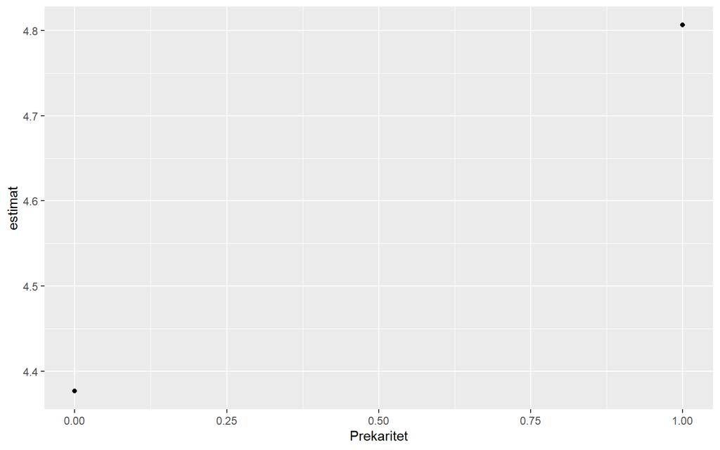

```r
#hent pakken fra biblioteket
library(ggplot2)

#opprett et tomt ark
ggplot(dfp) +
  #legg til punkter
  geom_point(aes(
    #De predikerte y-verdiene
    y = estimat,
    #Ulike scenarier
    x = Prekaritet))
```

**Legg så på usikkerheten** Her vil jeg illustrere usikkerheten/prediksjonsintervallet med vertikale streker. ggplot har en egen funksjon for disse `geom_errorbar()`

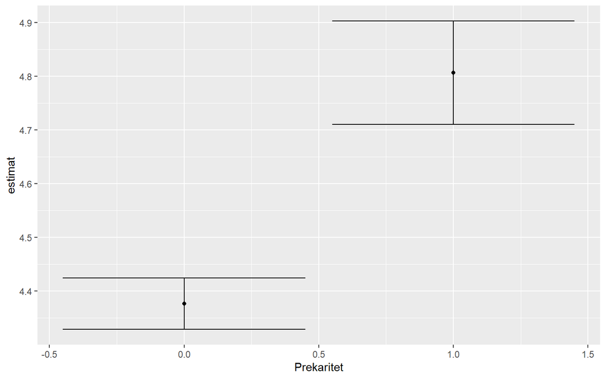

```r
library(ggplot2)

ggplot(dfp) +
  #Plott punktene
  geom_point(aes(
    #De predikerte y-verdiene
    y = estimat,
    #Ulike scenarier
    x = Prekaritet)
  ) +
  #Feilbarrer
  geom_errorbar(aes(
    #Scenariene
    x = Prekaritet,
    #Hvor søylen begynner
    ymin = lavmargin,
    #Hvor søylen ender
    ymax = hoymargin)
  )
```

Legg merke til hvordan ggplot tilpasser grenseverdiene til y-aksen når du legger på nye elementer. Dette kan du selvfølgelig overstyre med [estetiske “tweaks”] (https://siljehermansen.github.io/teaching/oslomet/sesjon10.html#tilrettelegging).

### Din tur!

Lek rundt med grafikken litt og sjekk ut tilleggsargumenter.

- Juster y-aksen med `ylim()`
- Juster aksenavnene med `ylab()`
- Tittel med `ggTitle()`
- Presiser størrelesen på de vertikale barrene i `geom_errorbar()` med `width=`
- legg til `theme_bw()` som siste funksjon i pipa. Du kan sjekke ut andre [estetiske tema](https://ggplot2.tidyverse.org/reference/ggtheme.html) på nettet.

## Scenarier på speed: kontinuerlige variabler

Når $x$-variaben vår er kontinuerlig, kan vi illustrere effekten som en regresjonslinje.

Dette er samme logikken som med to scenarier, men denne gangen lar vi inntekt gå fra lav til høy på kontinuerlig vis.

Jeg estimerer modellen min.

```r
mod1 <- lm(Skepsis ~
             Inntekt +
             Prekaritet,
           data = df)
```

### Definer scenarier

Nå definerer jeg nye scenarier. Jeg holder prekaritet konstant, men øker inntekt (variabelen jeg ønsker å illustrere).

Jeg kan bruke funksjonen `seq()` for å lage den nye variabelen. Jeg sier at laveste verdi er 0 og høyeste er 10. Deretter forteller jeg intervallene. Her har jeg valgt å lage et nytt scenario for hver 0.1 økning i inntekt. Jo lavere dette tallet er, jo “mykere” blir regresjonsstreken. Dette er først og fremst et poeng når vi illustrerer ikke-lineære sammenhenger.

```r
seq(from = 0,
    to = 10,
    by = 0.1)
```

I datasettet, vil `data.frame()`- funksjonen “resirkulere de korteste variablene. Det vil si at jeg ikke trenger å gi 101 verdier til”prekaritet”-variabelen min.

```r
nyedata <- data.frame(
  #hold prekaritet konstant
  Prekaritet = c(0),
  #la inntekt gå fra 0 til 10
  Inntekt = seq(from = 0,
                to = 10,
                by = 0.1))
head(nyedata)
```

|  | Prekaritet | Inntekt |
| --- | --- | --- |
| 1 | 0 | 0.0 |
| 2 | 0 | 0.1 |
| 3 | 0 | 0.2 |
| 4 | 0 | 0.3 |
| 5 | 0 | 0.4 |
| 6 | 0 | 0.5 |

Prediker utfallene for hvert scenario og ta vare på disse. Dette er ren copy-paste fra tidligere, unntatt modellobjektet

```r
predikerte <- predict(mod1,
                      newdata = nyedata,
                      se = TRUE)
#Opprett et nytt datasett
dfp = nyedata

dfp$estimat <- predikerte$fit
dfp$hoymargin <- predikerte$fit + predikerte$se.fit
dfp$lavmargin <- predikerte$fit - predikerte$se.fit
```

### Plot resultatene.

Denne gangen ønsker vi å plotte linjer og “gardiner” med usikkerhet; ikke punkter og streker/barrer.

Jeg begynner med regresjonslinjen:

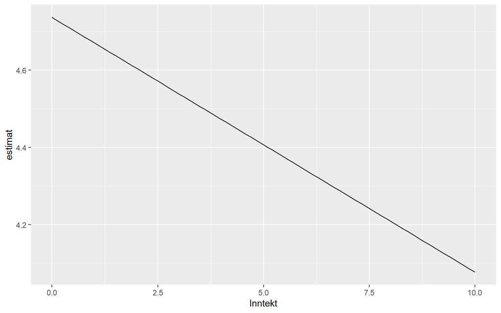

```r
ggplot(dfp) +
  geom_line(aes(
    y = estimat,
    x = Inntekt)
  )
```

Deretter legger jeg på usikkerheten. Dette kan jeg gjøre på to vis: som et farget område rundt regresjonslinjen, eller som stipulerte streker.

**En gardin av usikkerhet** Funksjonen `geom_ribbon()` fargelegger det usikre området. Det beste her, er å la fargen være gjennomsiktig.

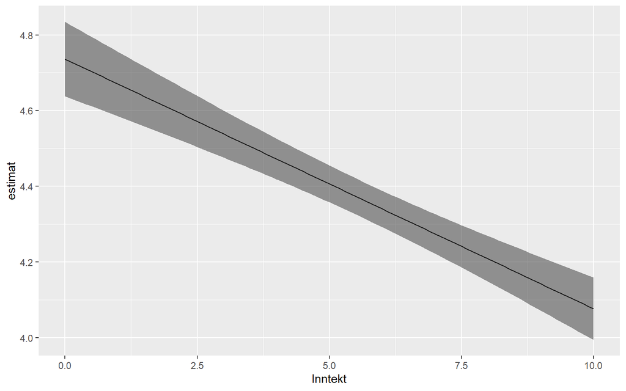

```r
ggplot(dfp) +
  geom_line(aes(
    y = estimat,
    x = Inntekt)
  ) +
  geom_ribbon(aes(ymax = hoymargin,
                  ymin = lavmargin,
                  x = Inntekt),
              #gjennomsiktig
              alpha = 0.5)
```

Her kan vi notere oss en nyanse i ggplots estestike logikk.

1. Vi kan definere *samme* estetiske elementer (farge, gjennomsiktighet, strektype…) for alle streker/elementer i geom_-funksjonen. Da gir vi tilleggsargumentene utenfor aes()-funksjonen. (`geom_ribbon(aes(x, y), alpha = =.5)`)
2. Vi kan også definere *unike* estetiske elementer for alle sreker i geom_-funksjonen. Da gir vi tilleggsargumentene innenfor aes() funksjonen. Det betyr at når vi har flere regresjonsstreker, så kan vi gi hver av dem en ulik farge/form. Da er det viktig å definere like mange former/farger som du har regresjonsstreker (`geom_ribbon(aes(x, y, alpha = =.5))`)

**Stipulerte streker som usikkerhet**. Om jeg ønsker stipulerte streker, vil jeg måtte legge dem inn én etter én.

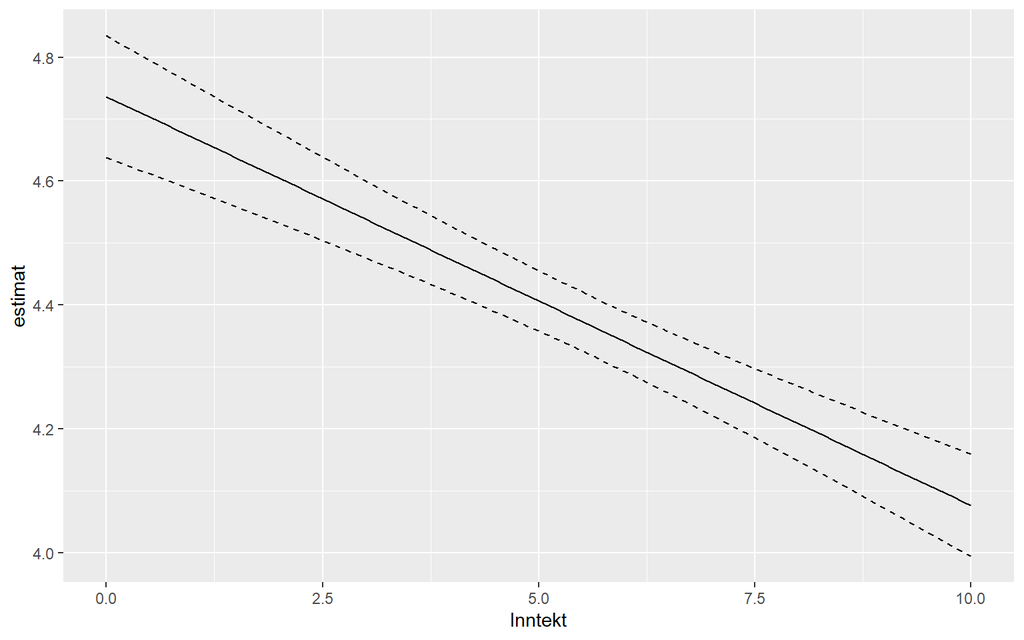

```r
ggplot(dfp) +
  geom_line(aes(
    y = estimat,
    x = Inntekt)
  ) +
  #hoyeste grenseverdi
  geom_line(aes(
    y = hoymargin,
    x = Inntekt),
    lty = 2 #stipulert linje
  ) +
  #laveste grenseverdi
  geom_line(aes(
    y = lavmargin,
    x = Inntekt),
    lty = 2 #stipulert linje
  )
```